# Yuxuan Gou-final project

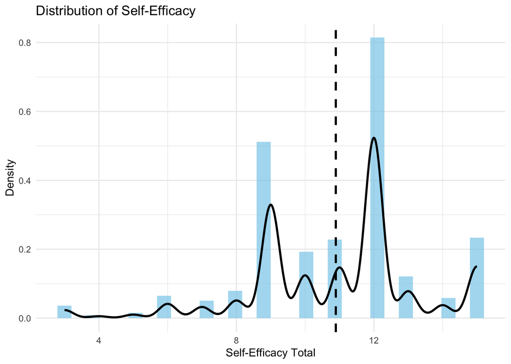

```r
# 1. self_efficacy distribution
ggplot(data1, aes(x = self_efficacy_total)) +
  geom_histogram(aes(y = ..density..), bins = 30, fill = "skyblue", alpha = 0.7) +
  geom_density(linewidth = 1) +
  geom_vline(aes(xintercept = mean(self_efficacy_total, na.rm = TRUE)),
             linetype = "dashed", linewidth = 1) +
  labs(
    title = "Distribution of Self-Efficacy",
    x = "Self-Efficacy Total",
    y = "Density"
  ) +
  theme_minimal()
```

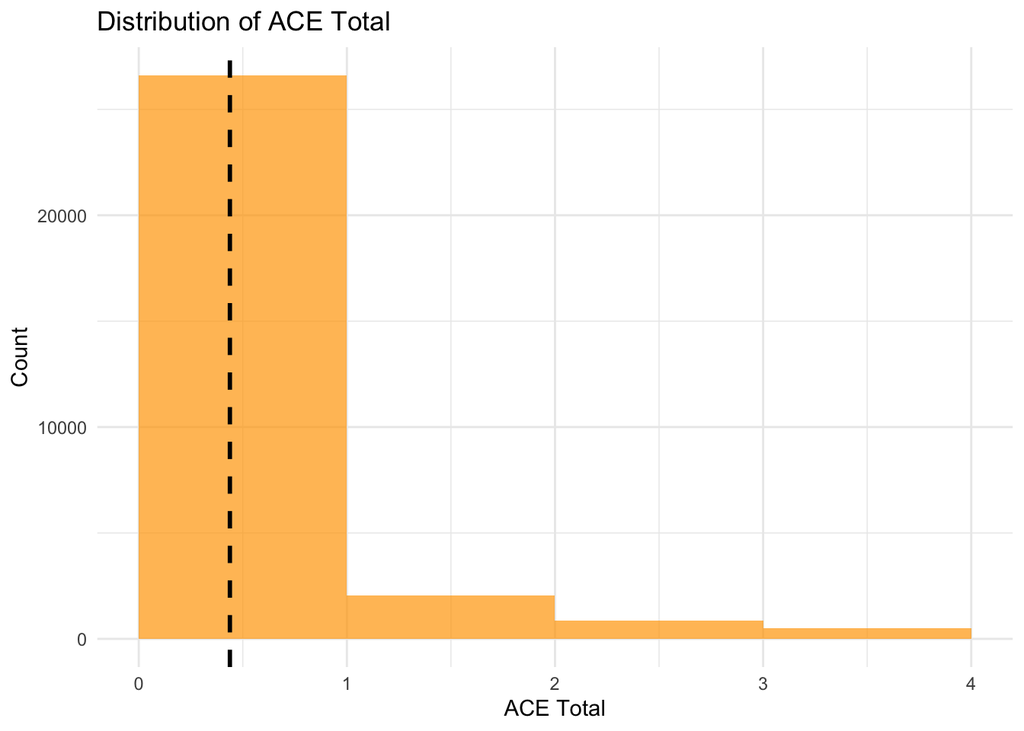

```r
# 2. ACE distribution
ggplot(data1, aes(x = ACE_total)) +
  geom_histogram(binwidth = 1, boundary = 0, fill = "orange", alpha = 0.7) +
  geom_vline(aes(xintercept = mean(ACE_total, na.rm = TRUE)),
             linetype = "dashed", linewidth = 1) +
  labs(
    title = "Distribution of ACE Total",
    x = "ACE Total",
    y = "Count"
  ) +
  theme_minimal()
```

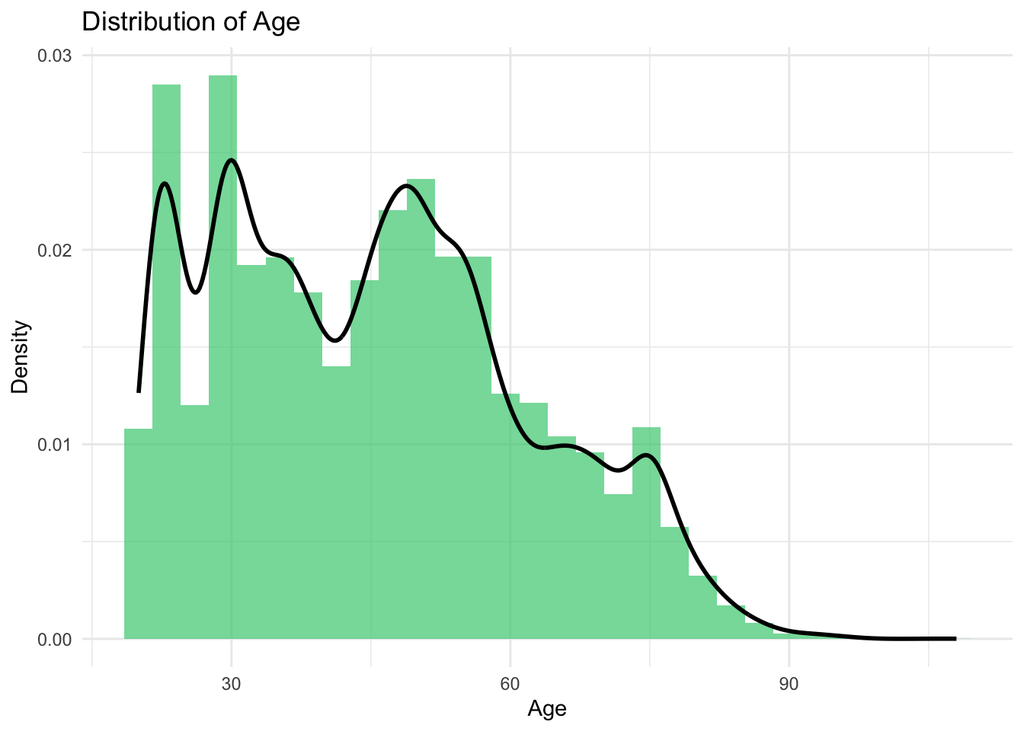

```r
# 3. age distribution
ggplot(data1, aes(x = `age`)) +
  geom_histogram(aes(y = ..density..), bins = 30, fill = "seagreen3", alpha = 0.7) +
  geom_density(linewidth = 1) +
  labs(
    title = "Distribution of Age",
    x = "Age",
    y = "Density"
  ) +
  theme_minimal()
```

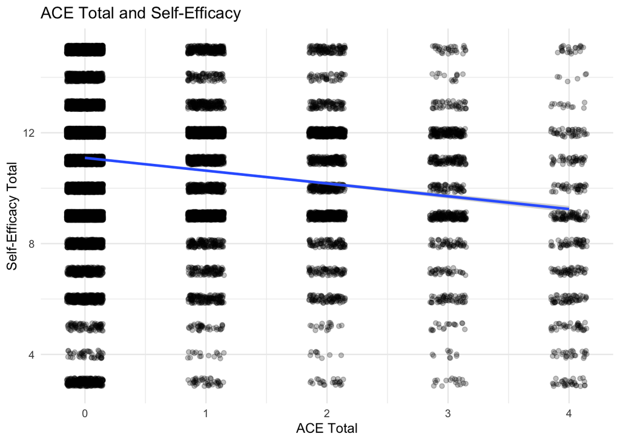

```r
# 4. ACE vs self-efficacy
ggplot(data1, aes(x = ACE_total, y = self_efficacy_total)) +
  geom_jitter(alpha = 0.25, width = 0.15, height = 0.15) +
  geom_smooth(method = "lm", se = TRUE, linewidth = 1) +
  labs(
    title = "ACE Total and Self-Efficacy",
    x = "ACE Total",
    y = "Self-Efficacy Total"
  ) +
  theme_minimal()
```

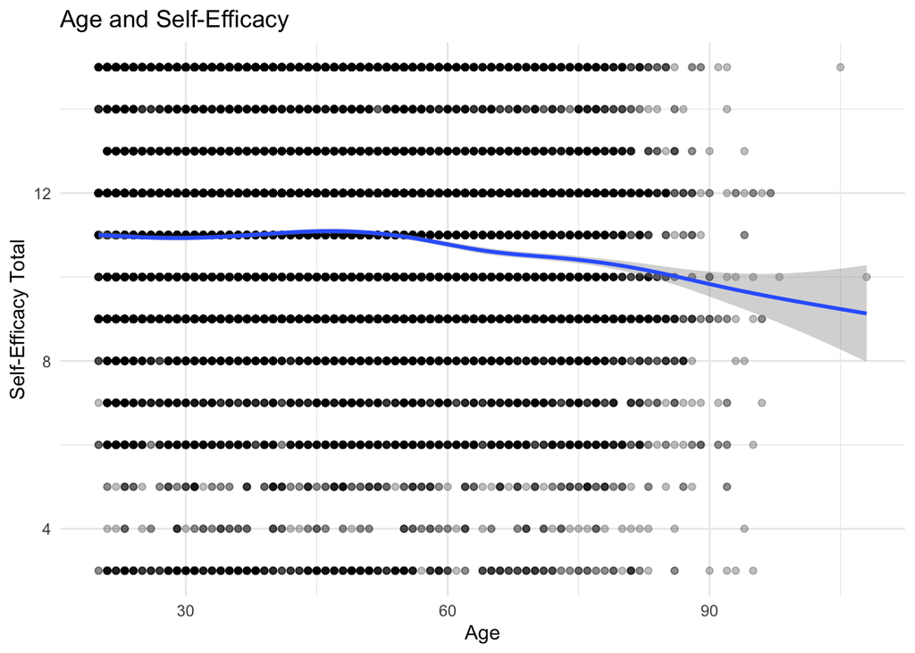

```r
# 5. age vs self-efficacy
ggplot(data1, aes(x = `年龄`, y = self_efficacy_total)) +
  geom_point(alpha = 0.25) +
  geom_smooth(se = TRUE, linewidth = 1) +
  labs(
    title = "Age and Self-Efficacy",
    x = "Age",
    y = "Self-Efficacy Total"
  ) +
  theme_minimal()
```

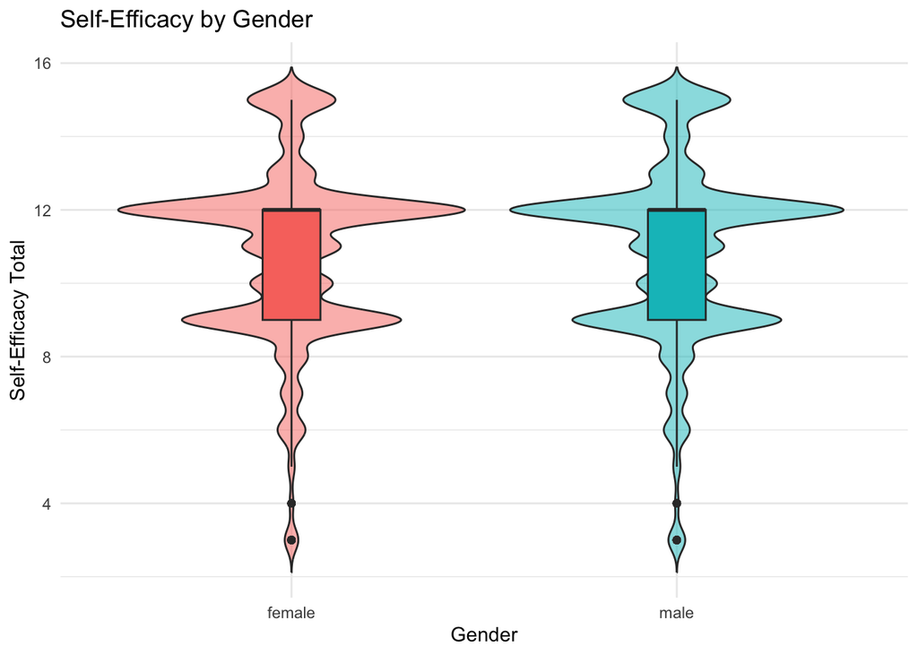

```r
# 6. self-efficacy by gender
ggplot(data1, aes(x = as.factor(gender), y = self_efficacy_total, fill = as.factor(gender))) +
  geom_violin(alpha = 0.5, trim = FALSE) +
  geom_boxplot(width = 0.15, outlier.alpha = 0.25) +
  labs(
    title = "Self-Efficacy by Gender",
    x = "Gender",
    y = "Self-Efficacy Total"
  ) +
  theme_minimal() +
  theme(legend.position = "none")
```

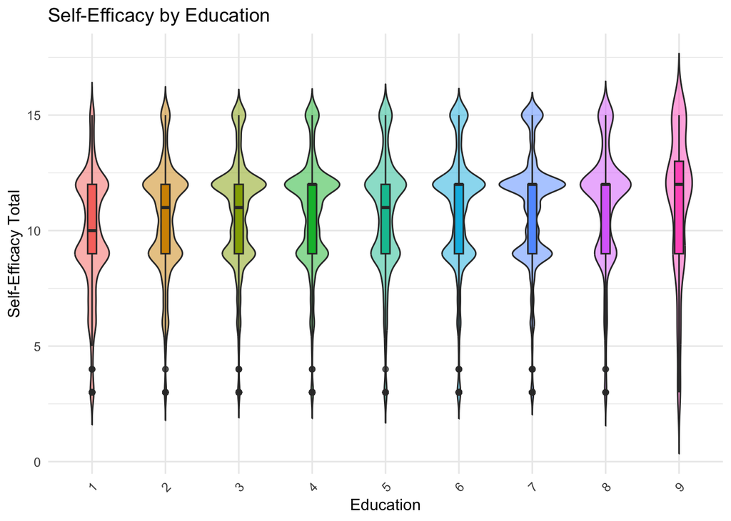

```r
# 7. self-efficacy by education
ggplot(data1, aes(x = as.factor(education), y = self_efficacy_total, fill = as.factor(education))) +
  geom_violin(alpha = 0.5, trim = FALSE) +
  geom_boxplot(width = 0.12, outlier.alpha = 0.2) +
  labs(
    title = "Self-Efficacy by Education",
    x = "Education",
    y = "Self-Efficacy Total"
  ) +
  theme_minimal() +
  theme(
    legend.position = "none",
    axis.text.x = element_text(angle = 45, hjust = 1)
  )
```

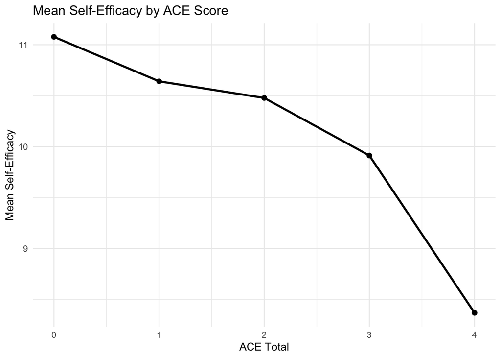

```r
# 8. mean self-efficacy by ACE score
ace_summary <- data1 |>
  filter(!is.na(ACE_total), !is.na(self_efficacy_total)) |>
  group_by(ACE_total) |>
  summarise(
    mean_self_efficacy = mean(self_efficacy_total),
    n = n(),
    .groups = "drop"
  )

ggplot(ace_summary, aes(x = ACE_total, y = mean_self_efficacy)) +
  geom_line(linewidth = 1) +
  geom_point(size = 2) +
  labs(
    title = "Mean Self-Efficacy by ACE Score",
    x = "ACE Total",
    y = "Mean Self-Efficacy"
  ) +
  theme_minimal()
```

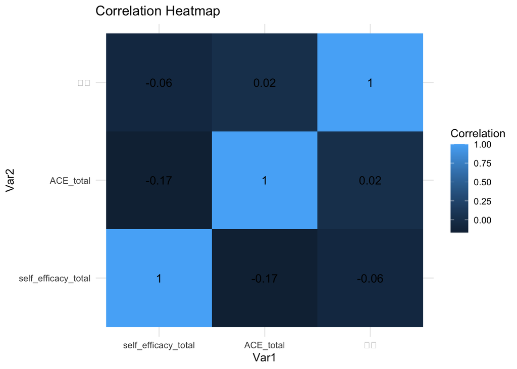

```r
# 9. correlation heatmap
cor_data <- data1 |>
  select(self_efficacy_total, ACE_total, `年龄`) |>
  na.omit()

cor_mat <- cor(cor_data)

cor_df <- as.data.frame(as.table(cor_mat))
names(cor_df) <- c("Var1", "Var2", "Correlation")

ggplot(cor_df, aes(x = Var1, y = Var2, fill = Correlation)) +
  geom_tile() +
  geom_text(aes(label = round(Correlation, 2)), size = 4) +
  labs(
    title = "Correlation Heatmap"
  ) +
  theme_minimal()
```

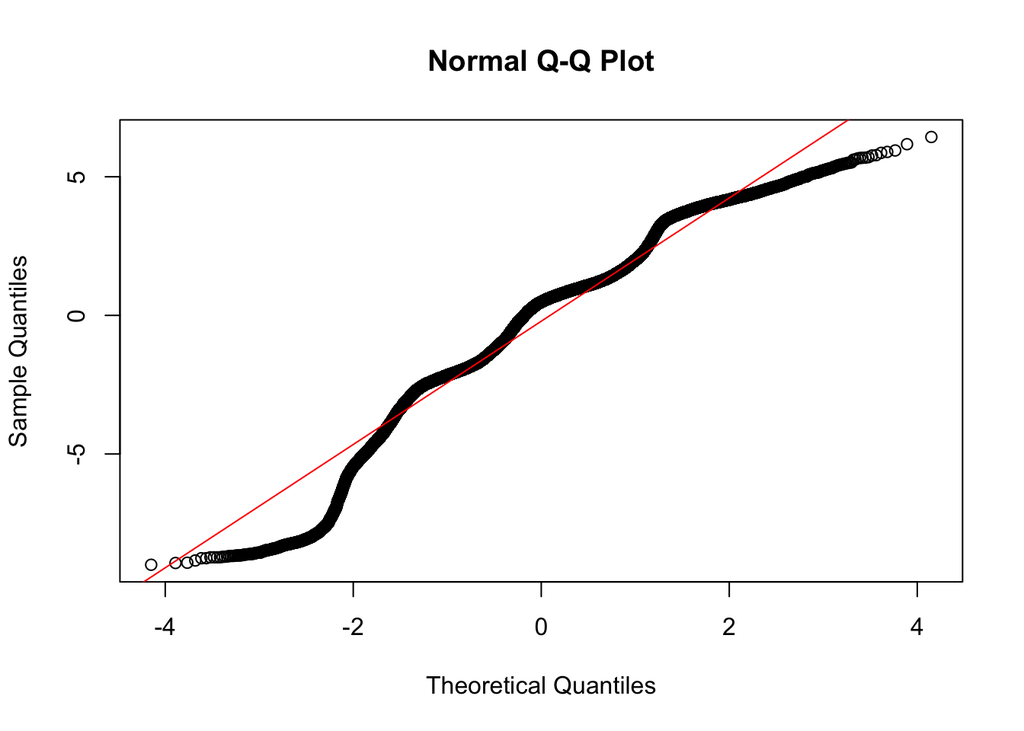

```r
model <- lm(self_efficacy_total ~ ACE_total + age + gender + education + income_ord + hukou + marital, data = model_data)

qqnorm(resid(model))
qqline(resid(model), col = "red")
```

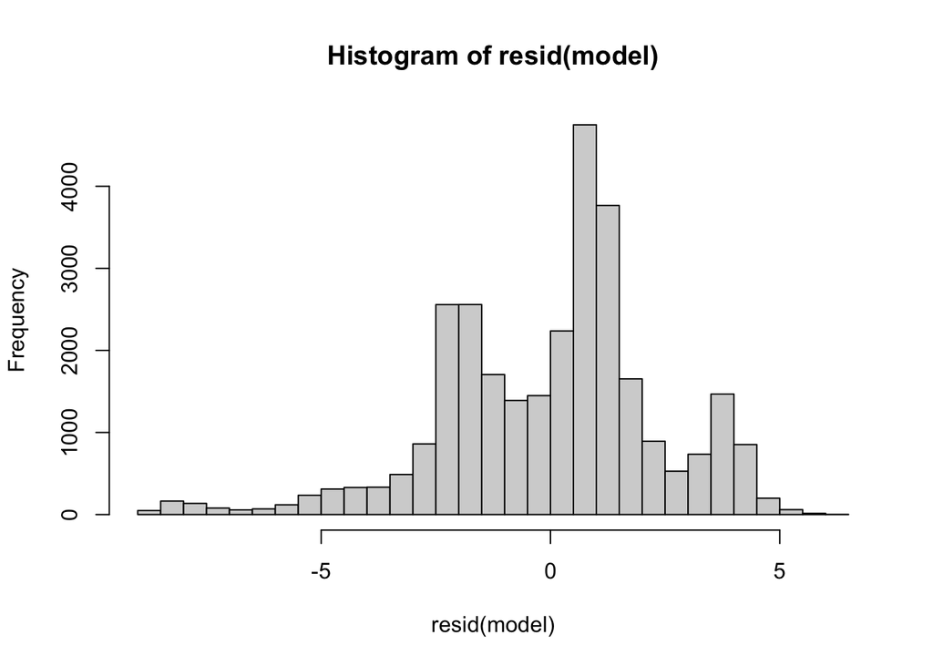

```r
hist(resid(model), breaks = 30)
```

Random Forest Model

```r
# =========================================================
# Tune Random Forest hyperparameters for full model
# Purpose:
# 1. Split data into training and test sets.
# 2. Use cross-validation on the training set.
# 3. Tune mtry and min_n for random forest regression.
# 4. Select the best hyperparameters based on RMSE.
# =========================================================

library(tidymodels)
library(dplyr)

set.seed(123)

rf_data <- data1 |>
  select(
    pss4_total,
    age, gender, education, income_ord, hukou, marital, employment,
    bmi, EQ_VAS, sleep_quality, MEQtotal_new,
    phq9_total, gad7_total, social_support_total, self_efficacy_total,
    resilience_total, family_support_total,
    live_alone, any_life_event, debt_any, ACE_total,
    drinking, smoking, chronic_disease
  ) |>
  filter(if_all(everything(), ~ !is.na(.)))

split <- initial_split(rf_data, prop = 0.8)
train_data <- training(split)
test_data  <- testing(split)

folds <- vfold_cv(train_data, v = 5)

rf_recipe <- recipe(pss4_total ~ ., data = train_data) |>
  step_dummy(all_nominal_predictors())

rf_spec <- rand_forest(
  mtry = tune(),
  min_n = tune(),
  trees = 500
) |>
  set_engine("ranger") |>
  set_mode("regression")

rf_workflow <- workflow() |>
  add_recipe(rf_recipe) |>
  add_model(rf_spec)

rf_grid <- grid_regular(
  mtry(range = c(3, 15)),
  min_n(range = c(5, 30)),
  levels = 5
)

rf_tuned <- tune_grid(
  rf_workflow,
  resamples = folds,
  grid = rf_grid,
  metrics = metric_set(rmse, rsq)
)

collect_metrics(rf_tuned)
```

```
## # A tibble: 50 × 8
##     mtry min_n .metric .estimator  mean     n std_err .config
##    <int> <int> <chr>   <chr>      <dbl> <int>   <dbl> <chr>
##  1     3     5 rmse    standard   2.21      5 0.0123  pre0_mod01_post0
##  2     3     5 rsq     standard   0.651     5 0.00383 pre0_mod01_post0
##  3     3    11 rmse    standard   2.21      5 0.0121  pre0_mod02_post0
##  4     3    11 rsq     standard   0.649     5 0.00403 pre0_mod02_post0
##  5     3    17 rmse    standard   2.22      5 0.0118  pre0_mod03_post0
##  6     3    17 rsq     standard   0.648     5 0.00385 pre0_mod03_post0
##  7     3    23 rmse    standard   2.22      5 0.0124  pre0_mod04_post0
##  8     3    23 rsq     standard   0.648     5 0.00393 pre0_mod04_post0
##  9     3    30 rmse    standard   2.23      5 0.0112  pre0_mod05_post0
## 10     3    30 rsq     standard   0.647     5 0.00392 pre0_mod05_post0
## # ℹ 40 more rows
```

```r
best_rf <- select_best(rf_tuned, metric = "rmse")
best_rf
```

```
## # A tibble: 1 × 3
##    mtry min_n .config
##   <int> <int> <chr>
## 1     9    17 pre0_mod13_post0
```

```r
final_rf_workflow <- finalize_workflow(rf_workflow, best_rf)

final_rf_fit <- fit(final_rf_workflow, data = train_data)

rf_test_pred <- predict(final_rf_fit, new_data = test_data) |>
  bind_cols(test_data |> select(pss4_total))

metrics(rf_test_pred, truth = pss4_total, estimate = .pred)
```

```
## # A tibble: 3 × 3
##   .metric .estimator .estimate
##   <chr>   <chr>          <dbl>
## 1 rmse    standard       2.18
## 2 rsq     standard       0.651
## 3 mae     standard       1.64
```

SHAP for full-RF

```r
library(fastshap)
```

```r
library(ggplot2)
library(tidyr)

# =========================================================
# Step 1. Sample observations from the training set for SHAP
# Purpose:
# Computing SHAP for all observations can be slow.
# A random subsample is usually enough for interpretation.
# =========================================================

set.seed(123)

shap_data <- train_data |>
  slice_sample(n = 1000)

X_shap <- shap_data |>
  select(-pss4_total)

# =========================================================
# Step 2. Define a prediction wrapper
# Purpose:
# Tell fastshap how to generate predictions from the fitted
# workflow object.
# =========================================================

pred_wrapper <- function(object, newdata) {
  predict(object, new_data = newdata)$.pred
}


# =========================================================
# Step 3. Compute SHAP values
# Purpose:
# Estimate approximate SHAP values for each predictor in the
# sampled observations.
# =========================================================

set.seed(123)

shap_values <- fastshap::explain(
  object = final_rf_fit,
  X = X_shap,
  pred_wrapper = pred_wrapper,
  nsim = 50,
  adjust = TRUE
)

head(shap_values)
```

```
##              age       gender    education   income_ord        hukou
## [1,] -0.07793186 -0.012740139  0.029110269  0.029377312  0.011310570
## [2,] -0.05202122  0.003623307  0.006462736 -0.025110626  0.001972605
## [3,] -0.03738214  0.012632012 -0.089717501 -0.024942299 -0.016614105
## [4,] -0.07156649  0.011285439 -0.015790904 -0.033117909  0.007663391
## [5,]  0.05773245  0.004552558  0.004721661  0.003957579 -0.006541553
## [6,]  0.14263867  0.004677510  0.015407024  0.025905438  0.007097718
##           marital  employment         bmi        EQ_VAS sleep_quality
## [1,] -0.028408081  0.04294822 -0.07784855  0.0231333521  -0.048881493
## [2,] -0.054763311 -0.01374856  0.16807137 -0.0190472134  -0.011793220
## [3,]  0.047694823  0.04459065 -0.01933427 -0.0245558055  -0.015365589
## [4,] -0.016508384 -0.04456689  0.03102026 -0.0612842443   0.002214541
## [5,]  0.004941014 -0.02280415 -0.04208916 -0.0064385716   0.023821001
## [6,]  0.045911069  0.20771161  0.07969832  0.0001422067   0.047709382
##      MEQtotal_new  phq9_total gad7_total social_support_total
```

[output cut: 27 more lines]

```r
dim(shap_values)
```

```
## [1] 1000   24
```

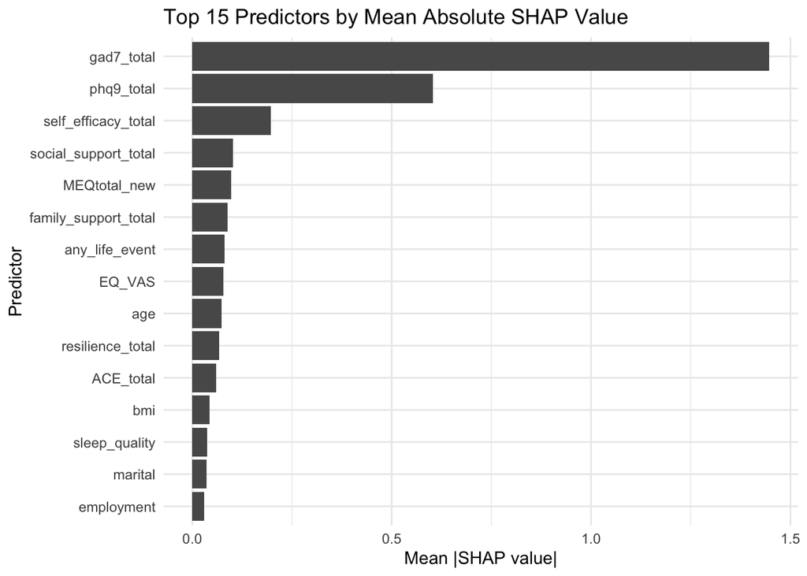

```r
# =========================================================
# Step 4. Global SHAP importance plot
# Purpose:
# Rank predictors by their average absolute SHAP values.
# Larger values indicate greater overall importance.
# =========================================================

shap_importance <- data.frame(
  variable = colnames(shap_values),
  mean_abs_shap = apply(abs(shap_values), 2, mean)
) |>
  arrange(desc(mean_abs_shap))

ggplot(
  shap_importance |> slice_max(order_by = mean_abs_shap, n = 15),
  aes(x = reorder(variable, mean_abs_shap), y = mean_abs_shap)
) +
  geom_col() +
  coord_flip() +
  labs(
    title = "Top 15 Predictors by Mean Absolute SHAP Value",
    x = "Predictor",
    y = "Mean |SHAP value|"
  ) +
  theme_minimal()
```

```r
shap_importance |>
  slice_max(order_by = mean_abs_shap, n = 10)
```

```
##                                  variable mean_abs_shap
## gad7_total                     gad7_total    1.44717995
## phq9_total                     phq9_total    0.60388436
## self_efficacy_total   self_efficacy_total    0.19728762
## social_support_total social_support_total    0.10131383
## MEQtotal_new                 MEQtotal_new    0.09703674
## family_support_total family_support_total    0.08812930
## any_life_event             any_life_event    0.08063502
## EQ_VAS                             EQ_VAS    0.07792998
## age                                   age    0.07289504
## resilience_total         resilience_total    0.06719944
```

Lasso-RF

```r
# =========================================================
# Random Forest using LASSO-selected predictors
# Purpose:
# 1. Use only the predictors retained by LASSO at lambda.1se.
# 2. Split the data into training and test sets.
# 3. Tune random forest hyperparameters using 5-fold CV.
# 4. Fit the final model and evaluate predictive performance.
# =========================================================

library(tidymodels)
library(dplyr)

set.seed(123)

# ---------------------------------------------------------
# Step 1. Build the analysis dataset using LASSO-selected
# original variables.
# Note:
# - employmentstudent came from employment
# - any_life_eventYes came from any_life_event
# - as.numeric(EQ_VAS) is treated here as EQ_VAS numeric
# ---------------------------------------------------------
rf_lasso_data <- data1 |>
  select(
    pss4_total,
    income_ord,
    employment,
    EQ_VAS,
    MEQtotal_new,
    phq9_total,
    gad7_total,
    self_efficacy_total,
    family_support_total,
    any_life_event,
    ACE_total
  ) |>
  mutate(
    EQ_VAS = as.numeric(EQ_VAS)
  ) |>
  filter(if_all(everything(), ~ !is.na(.)))

# Convert categorical predictors to factors
rf_lasso_data$employment <- as.factor(rf_lasso_data$employment)
rf_lasso_data$any_life_event <- as.factor(rf_lasso_data$any_life_event)

# Optional check
str(rf_lasso_data)
```

```
## tibble [30,054 × 11] (S3: tbl_df/tbl/data.frame)
##  $ pss4_total          : num [1:30054] 15 2 8 10 12 4 0 14 5 0 ...
##  $ income_ord          : num [1:30054] 6 6 2 6 4 1 10 5 10 10 ...
##  $ employment          : Factor w/ 5 levels "employed","flexible_job",..: 4 4 4 5 4 4 4 1 5 4 ...
##  $ EQ_VAS              : num [1:30054] 61 77 71 44 95 92 100 86 100 79 ...
##  $ MEQtotal_new        : num [1:30054] 8 18 11 16 11 14 11 17 18 13 ...
##  $ phq9_total          : num [1:30054] 22 6 10 18 17 8 5 21 4 4 ...
##  $ gad7_total          : num [1:30054] 20 6 9 12 11 5 0 7 4 0 ...
##  $ self_efficacy_total : num [1:30054] 10 11 12 6 12 12 15 13 13 12 ...
##  $ family_support_total: num [1:30054] 37 50 38 25 44 40 50 31 50 50 ...
##  $ any_life_event      : Factor w/ 2 levels "No","Yes": 2 2 2 2 2 2 1 2 1 1 ...
##  $ ACE_total           : num [1:30054] 1 2 2 2 2 0 2 1 0 0 ...
```

```r
# ---------------------------------------------------------
# Step 2. Split into training and test sets
# ---------------------------------------------------------
split_lasso <- initial_split(rf_lasso_data, prop = 0.8)
train_lasso <- training(split_lasso)
test_lasso  <- testing(split_lasso)

# ---------------------------------------------------------
# Step 3. Create 5-fold CV on the training set
# ---------------------------------------------------------
folds_lasso <- vfold_cv(train_lasso, v = 5)

# ---------------------------------------------------------
# Step 4. Define the recipe
# step_novel() helps handle unseen factor levels in resamples.
# step_dummy() converts categorical predictors into dummies.
# ---------------------------------------------------------
rf_lasso_recipe <- recipe(pss4_total ~ ., data = train_lasso) |>
  step_novel(all_nominal_predictors()) |>
  step_dummy(all_nominal_predictors())

# ---------------------------------------------------------
# Step 5. Define the random forest model
# We tune mtry and min_n, and keep trees fixed at 500.
# ---------------------------------------------------------
rf_lasso_spec <- rand_forest(
  mtry = tune(),
  min_n = tune(),
  trees = 500
) |>
  set_engine("ranger") |>
  set_mode("regression")

# ---------------------------------------------------------
# Step 6. Create workflow
# ---------------------------------------------------------
rf_lasso_workflow <- workflow() |>
  add_recipe(rf_lasso_recipe) |>
  add_model(rf_lasso_spec)

# ---------------------------------------------------------
# Step 7. Define the tuning grid
# Since the model uses fewer predictors, the mtry range
# can be set smaller than in the full RF model.
# ---------------------------------------------------------
rf_lasso_grid <- grid_regular(
  mtry(range = c(1, 8)),
  min_n(range = c(5, 25)),
  levels = 5
)

# ---------------------------------------------------------
# Step 8. Tune hyperparameters using 5-fold CV
# ---------------------------------------------------------
rf_lasso_tuned <- tune_grid(
  rf_lasso_workflow,
  resamples = folds_lasso,
  grid = rf_lasso_grid,
  metrics = metric_set(rmse, rsq)
)

# View tuning results
collect_metrics(rf_lasso_tuned)
```

```
## # A tibble: 50 × 8
##     mtry min_n .metric .estimator  mean     n std_err .config
##    <int> <int> <chr>   <chr>      <dbl> <int>   <dbl> <chr>
##  1     1     5 rmse    standard   2.95      5 0.0169  pre0_mod01_post0
##  2     1     5 rsq     standard   0.572     5 0.00472 pre0_mod01_post0
##  3     1    10 rmse    standard   2.97      5 0.0143  pre0_mod02_post0
##  4     1    10 rsq     standard   0.571     5 0.00449 pre0_mod02_post0
##  5     1    15 rmse    standard   2.97      5 0.0206  pre0_mod03_post0
##  6     1    15 rsq     standard   0.569     5 0.00288 pre0_mod03_post0
##  7     1    20 rmse    standard   2.97      5 0.0198  pre0_mod04_post0
##  8     1    20 rsq     standard   0.568     5 0.00370 pre0_mod04_post0
##  9     1    25 rmse    standard   2.93      5 0.0149  pre0_mod05_post0
## 10     1    25 rsq     standard   0.574     5 0.00556 pre0_mod05_post0
## # ℹ 40 more rows
```

```r
# ---------------------------------------------------------
# Step 9. Select the best hyperparameters based on RMSE
# ---------------------------------------------------------
best_rf_lasso <- select_best(rf_lasso_tuned, metric = "rmse")
best_rf_lasso
```

```
## # A tibble: 1 × 3
##    mtry min_n .config
##   <int> <int> <chr>
## 1     4    25 pre0_mod15_post0
```

```r
# ---------------------------------------------------------
# Step 10. Finalize workflow with best hyperparameters
# and fit on the full training set
# ---------------------------------------------------------
final_rf_lasso_workflow <- finalize_workflow(
  rf_lasso_workflow,
  best_rf_lasso
)

final_rf_lasso_fit <- fit(final_rf_lasso_workflow, data = train_lasso)

# ---------------------------------------------------------
# Step 11. Evaluate the final model on the test set
# ---------------------------------------------------------
rf_lasso_test_pred <- predict(final_rf_lasso_fit, new_data = test_lasso) |>
  bind_cols(test_lasso |> select(pss4_total))

metrics(rf_lasso_test_pred, truth = pss4_total, estimate = .pred)
```

```
## # A tibble: 3 × 3
##   .metric .estimator .estimate
##   <chr>   <chr>          <dbl>
## 1 rmse    standard       2.17
## 2 rsq     standard       0.654
## 3 mae     standard       1.65
```

The random forest model using the LASSO-selected predictors achieved its best performance with mtry = 4 and min_n = 25. On the held-out test set, the model yielded an RMSE of 2.17, an R² of 0.654, and an MAE of 1.65. Compared with the full random forest model, the LASSO-based random forest performed very similarly, with slightly lower RMSE and slightly higher R². This suggests that the smaller set of predictors retained by LASSO captured most of the predictive signal in perceived stress, allowing for a more parsimonious model without meaningful loss of performance.